# 326.212 Final Project: Part 2

## 2019-14500 최민준

```r
library(RSQLite)
library(tidyverse)
con <- dbConnect(SQLite(), "project.sqlite")
```

## Part 2. Basic Questions (150 pts)

### Q1. Monthly traffic in three airports (60 pts)

#### Q1-1

```r
airports <- tbl(con, "airports")

filter(airports, IATA == "SNA" | IATA == "SJC" | IATA == "SMF")
```

```
## # Source:   lazy query [?? x 14]
## # Database: sqlite 3.29.0
## #   [C:\Users\minjo\Documents\GitHub\sc19-hw-MinjoonChoi99\project\project.sqlite]
##   number name  city  country IATA  ICAO    lat  long elevation timezone letter
##    <dbl> <chr> <chr> <chr>   <chr> <chr> <dbl> <dbl>     <dbl>    <dbl> <chr>
## 1   3748 Norm~ San ~ United~ SJC   KSJC   37.4 -122.        62       -8 A
## 2   3817 Sacr~ Sacr~ United~ SMF   KSMF   38.7 -122.        27       -8 A
## 3   3867 John~ Sant~ United~ SNA   KSNA   33.7 -118.        56       -8 A
## # ... with 3 more variables: `continent/city` <chr>, airport <chr>,
## #   OurAirports <chr>
```

- SNA: John Wayne Airport-Orange County Airport
- SJC: Norman Y. Mineta San Jose International Airport
- SMF: Sacramento International Airport

#### Q1-2

```r
flights <- tbl(con, "flights")

airportcounts <- flights %>%
  filter(Dest == "SNA" | Dest == "SJC" | Dest == "SMF") %>%
  group_by(Year, Month, Dest) %>%
  summarise(count = n()) %>%
  collect()

airportcounts
```

```
## # A tibble: 648 x 4
## # Groups:   Year, Month [216]
##     Year Month Dest  count
##    <dbl> <dbl> <chr> <int>
##  1  2001     1 SJC    6321
##  2  2001     1 SMF    3325
##  3  2001     1 SNA    3726
##  4  2001     2 SJC    5720
##  5  2001     2 SMF    2930
##  6  2001     2 SNA    3327
##  7  2001     3 SJC    6426
##  8  2001     3 SMF    3342
##  9  2001     3 SNA    3676
## 10  2001     4 SJC    6202
## # ... with 638 more rows
```

#### Q1-3

```r
library(lubridate)
airportcounts <- airportcounts %>%
  mutate(Date = lubridate::make_date(Year, Month)) %>%
  arrange(Date)

airportcounts
```

```
## # A tibble: 648 x 5
## # Groups:   Year, Month [216]
##     Year Month Dest  count Date
##    <dbl> <dbl> <chr> <int> <date>
##  1  2001     1 SJC    6321 2001-01-01
##  2  2001     1 SMF    3325 2001-01-01
##  3  2001     1 SNA    3726 2001-01-01
##  4  2001     2 SJC    5720 2001-02-01
##  5  2001     2 SMF    2930 2001-02-01
##  6  2001     2 SNA    3327 2001-02-01
##  7  2001     3 SJC    6426 2001-03-01
##  8  2001     3 SMF    3342 2001-03-01
##  9  2001     3 SNA    3676 2001-03-01
## 10  2001     4 SJC    6202 2001-04-01
## # ... with 638 more rows
```

#### Q1-4

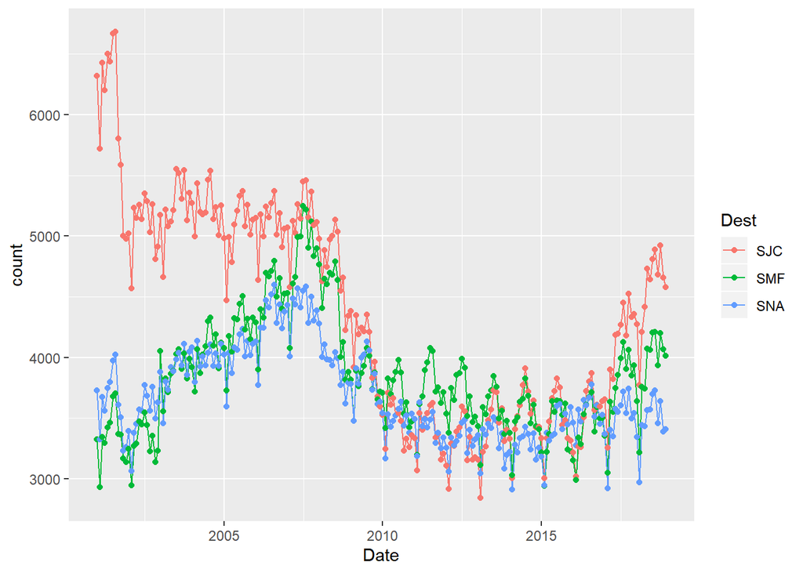

```r
ggplot(data = airportcounts, mapping = aes(x = Date, y = count, color = Dest)) +
  geom_line() +
  geom_point()
```

#### Q1-5

- For San Jose International Airport,

```r
filter(airportcounts, Dest == "SJC") %>%
  arrange(desc(count)) %>%
  head(10)
```

```
## # A tibble: 10 x 5
## # Groups:   Year, Month [10]
##     Year Month Dest  count Date
##    <dbl> <dbl> <chr> <int> <date>
##  1  2001     8 SJC    6682 2001-08-01
##  2  2001     7 SJC    6670 2001-07-01
##  3  2001     5 SJC    6501 2001-05-01
##  4  2001     6 SJC    6436 2001-06-01
##  5  2001     3 SJC    6426 2001-03-01
##  6  2001     1 SJC    6321 2001-01-01
##  7  2001     4 SJC    6202 2001-04-01
##  8  2001     9 SJC    5805 2001-09-01
##  9  2001     2 SJC    5720 2001-02-01
## 10  2001    10 SJC    5588 2001-10-01
```

- For Sacramento International Airport,

```r
filter(airportcounts, Dest == "SMF") %>%
  arrange(desc(count)) %>%
  head(10)
```

```
## # A tibble: 10 x 5
## # Groups:   Year, Month [10]
##     Year Month Dest  count Date
##    <dbl> <dbl> <chr> <int> <date>
##  1  2007     7 SMF    5245 2007-07-01
##  2  2007     8 SMF    5218 2007-08-01
##  3  2007    10 SMF    5120 2007-10-01
##  4  2007     6 SMF    4998 2007-06-01
##  5  2007     5 SMF    4993 2007-05-01
##  6  2007     9 SMF    4901 2007-09-01
##  7  2007    12 SMF    4897 2007-12-01
##  8  2007    11 SMF    4836 2007-11-01
##  9  2006     8 SMF    4793 2006-08-01
## 10  2008     7 SMF    4791 2008-07-01
```

- For Orange County Airport,

```r
filter(airportcounts, Dest == "SNA") %>%
  arrange(desc(count)) %>%
  head(10)
```

```
## # A tibble: 10 x 5
## # Groups:   Year, Month [10]
##     Year Month Dest  count Date
##    <dbl> <dbl> <chr> <int> <date>
##  1  2006     8 SNA    4598 2006-08-01
##  2  2007     8 SNA    4584 2007-08-01
##  3  2007     5 SNA    4568 2007-05-01
##  4  2007     7 SNA    4547 2007-07-01
##  5  2006     7 SNA    4519 2006-07-01
##  6  2007    10 SNA    4501 2007-10-01
##  7  2007     3 SNA    4486 2007-03-01
##  8  2006     5 SNA    4470 2006-05-01
##  9  2006    10 SNA    4435 2006-10-01
## 10  2007     4 SNA    4434 2007-04-01
```

### Q2. Finding reliable airlines (60 pts)

#### Q2-1

```r
delays <- flights %>%
  filter(Origin == "ORD" & Dest == "MSP") %>%
  filter(Year == 2015) %>%
  filter(Op_Unique_Carrier == "UA" | Op_Unique_Carrier == "DL" | Op_Unique_Carrier == "AA" | Op_Unique_Carrier == "MQ") %>%
  select(1, 2, 3, 9, 15) %>%  # selecting only necessary columns
  group_by(Year, Month, Day_of_Month, Op_Unique_Carrier) %>%
  summarise(avg_ArrDelay = mean(Arr_Delay), count = n()) %>%
  collect()
delays
```

```
## # A tibble: 1,193 x 6
## # Groups:   Year, Month, Day_of_Month [365]
##     Year Month Day_of_Month Op_Unique_Carrier avg_ArrDelay count
##    <dbl> <dbl>        <dbl> <chr>                    <dbl> <int>
##  1  2015     1            1 AA                      120.       3
##  2  2015     1            1 DL                      -12.5      2
##  3  2015     1            1 MQ                        2.33     3
##  4  2015     1            2 AA                      -10.5      3
##  5  2015     1            2 DL                       -1        3
##  6  2015     1            2 MQ                        3.33     3
##  7  2015     1            3 AA                      124.       3
##  8  2015     1            3 DL                       48.5      2
##  9  2015     1            3 MQ                       20        2
## 10  2015     1            4 AA                      101.       3
## # ... with 1,183 more rows
```

#### Q2-2

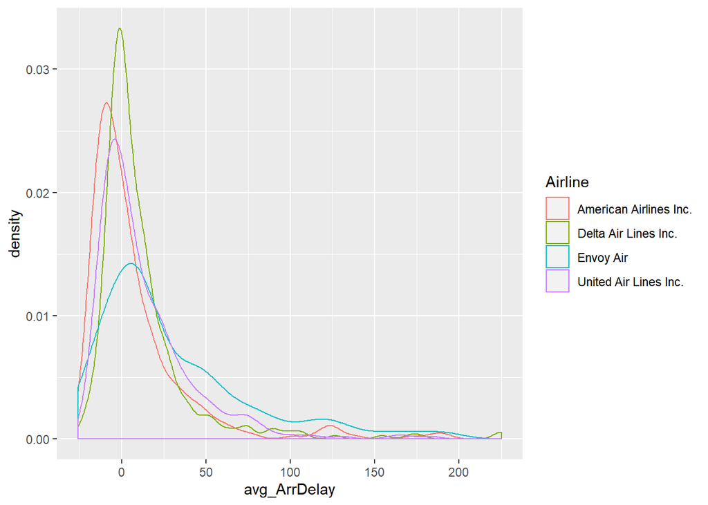

```r
airlines <- tbl(con, "airlines") %>%
  collect()

delays <- left_join(delays, airlines, by = c("Op_Unique_Carrier" = "Code"))
colnames(delays)[7] <- "Airline"

delays %>%
  ggplot() +
  geom_density(mapping = aes(x = avg_ArrDelay, color = Airline))
```

- It seems that American Air is the most reliable airline, because its density plot is most leftward (smallest average arrival-delay).
- The density plot of Envoy Air is certainly weighted to the right side compared to the other lines. This means that Envoy Air shows a bigger average arrival delay, and thus we can conclude that Envoy Air is the least reliable airline among these.
- In fact, Envoy Air is a regional airline in USA, while the others are major international carriers.

### Q3. All flights (30 pts)

#### Q3-1

```r
count_mondays_2001 <- flights %>%
  filter(Year == 2001 & Day_Of_Week == 1) %>%
  group_by(Year, Month, Day_of_Month) %>%
  summarise(count = n()) %>%
  collect() %>%
  mutate(Date = make_date(Year, Month, Day_of_Month))

count_mondays_2001
```

```
## # A tibble: 53 x 5
## # Groups:   Year, Month [12]
##     Year Month Day_of_Month count Date
##    <dbl> <dbl>        <dbl> <int> <date>
##  1  2001     1            1 16081 2001-01-01
##  2  2001     1            8 17491 2001-01-08
##  3  2001     1           15 17510 2001-01-15
##  4  2001     1           22 17534 2001-01-22
##  5  2001     1           29 17533 2001-01-29
##  6  2001     2            5 17473 2001-02-05
##  7  2001     2           12 17472 2001-02-12
##  8  2001     2           19 17343 2001-02-19
##  9  2001     2           26 17543 2001-02-26
## 10  2001     3            5 17570 2001-03-05
## # ... with 43 more rows
```

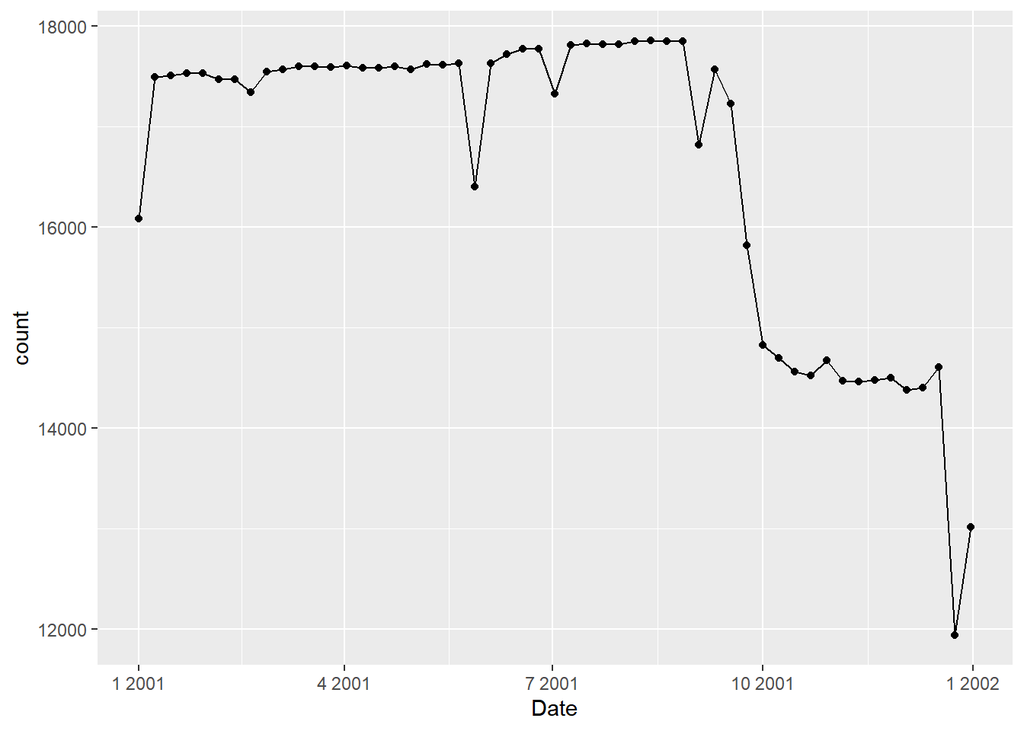

```r
ggplot(data = count_mondays_2001) +
  geom_point(aes(x = Date, y = count)) +
  geom_line(aes(x = Date, y = count))
```

```r
count_mondays_2001 %>%
  filter(count < 17000)
```

```
## # A tibble: 18 x 5
## # Groups:   Year, Month [6]
##     Year Month Day_of_Month count Date
##    <dbl> <dbl>        <dbl> <int> <date>
##  1  2001     1            1 16081 2001-01-01
##  2  2001     5           28 16405 2001-05-28
##  3  2001     9            3 16818 2001-09-03
##  4  2001     9           24 15818 2001-09-24
##  5  2001    10            1 14823 2001-10-01
##  6  2001    10            8 14698 2001-10-08
##  7  2001    10           15 14560 2001-10-15
##  8  2001    10           22 14521 2001-10-22
##  9  2001    10           29 14676 2001-10-29
## 10  2001    11            5 14467 2001-11-05
## 11  2001    11           12 14459 2001-11-12
## 12  2001    11           19 14479 2001-11-19
## 13  2001    11           26 14496 2001-11-26
## 14  2001    12            3 14381 2001-12-03
## 15  2001    12           10 14397 2001-12-10
## 16  2001    12           17 14602 2001-12-17
## 17  2001    12           24 11935 2001-12-24
## 18  2001    12           31 13014 2001-12-31
```

Let’s first explain the reasons of slightly decreased counts. - January 1st: New Years Day - May 28th: Memorial Day - September 3rd: Labor Day These are holidays in America, and this is the reason of the slight drops of counts of flights.

- The most interesting pattern is that there was a significant drop on number of flights from mid-September.
- The reason of this would be “9/11 terror attack” on the United States, which was on September 11th, 2001. Directly after this terrorist attack, the federal government closed airports, canceling thousands of flights. Even when the airports reopened, airlines experienced at least a 30 percent reduction in demand during the initial shock period. This might caused the airlines to reduce the number of flights.
- Also, December 24th is Christmas Eve, when people stay home. There is a rapid decrease in number of flights.
- December 31st, the day before New Years Day, also shows a relatively small number of flights.

#### Q3-2

```r
count_mondays_2011 <- flights %>%
  filter(Year == 2011 & Day_Of_Week == 1) %>%
  group_by(Year, Month, Day_of_Month) %>%
  summarise(count = n()) %>%
  collect() %>%
  mutate(Date = make_date(Year, Month, Day_of_Month))

count_mondays_2011
```

```
## # A tibble: 52 x 5
## # Groups:   Year, Month [12]
##     Year Month Day_of_Month count Date
##    <dbl> <dbl>        <dbl> <int> <date>
##  1  2011     1            3 17381 2011-01-03
##  2  2011     1           10 16743 2011-01-10
##  3  2011     1           17 16652 2011-01-17
##  4  2011     1           24 16695 2011-01-24
##  5  2011     1           31 16698 2011-01-31
##  6  2011     2            7 16881 2011-02-07
##  7  2011     2           14 16817 2011-02-14
##  8  2011     2           21 17157 2011-02-21
##  9  2011     2           28 17261 2011-02-28
## 10  2011     3            7 17420 2011-03-07
## # ... with 42 more rows
```

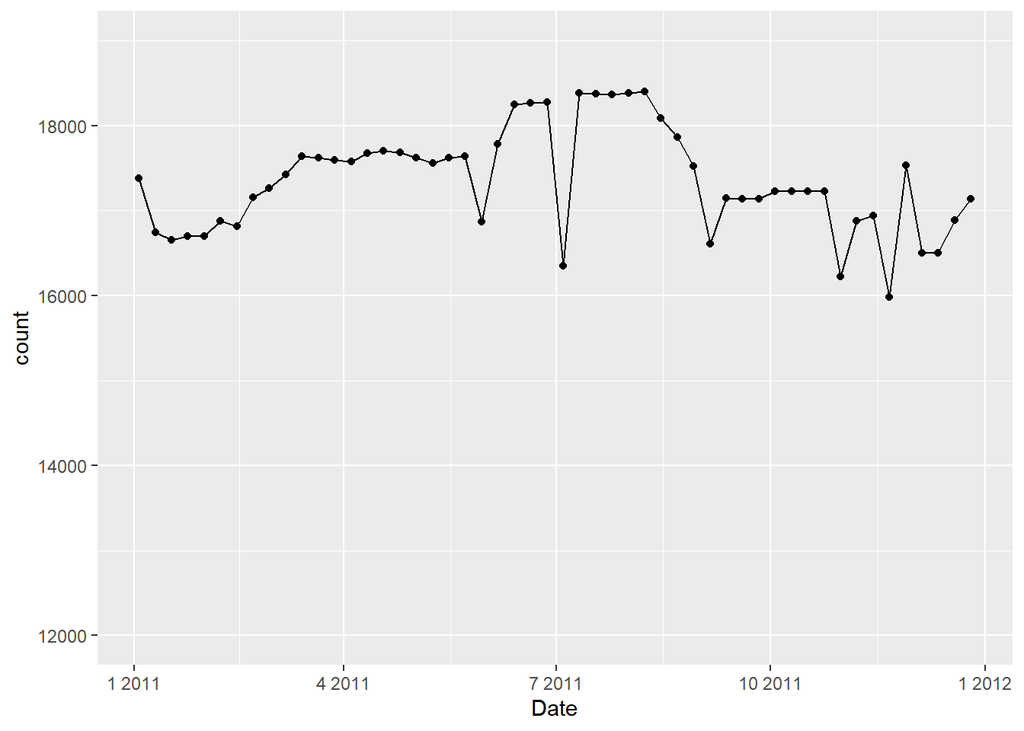

```r
ggplot(data = count_mondays_2011) +
  geom_point(aes(x = Date, y = count)) +
  geom_line(aes(x = Date, y = count)) +
  coord_cartesian(ylim = c(12000, 19000)) +
  scale_y_continuous(breaks = seq(12000, 18000, by = 2000))
```

- There are slight outliers, but no big rapid changes compared to 2001.

These are holidays, when people usually stay home. - May 30th: Memorial Day - July 4th: Independence Day - September 5th: Labor Day

- November 28th shows a noticeable increase, because it is the first Monday after Thanksgiving (Nov. 24). Many people visit their families during Thanksgiving and come back home, or to work.

```r
dbDisconnect(con)
```